# Homework #2

#### e) PCA

Perhaps PCA will be able to definitely separate the two groups.

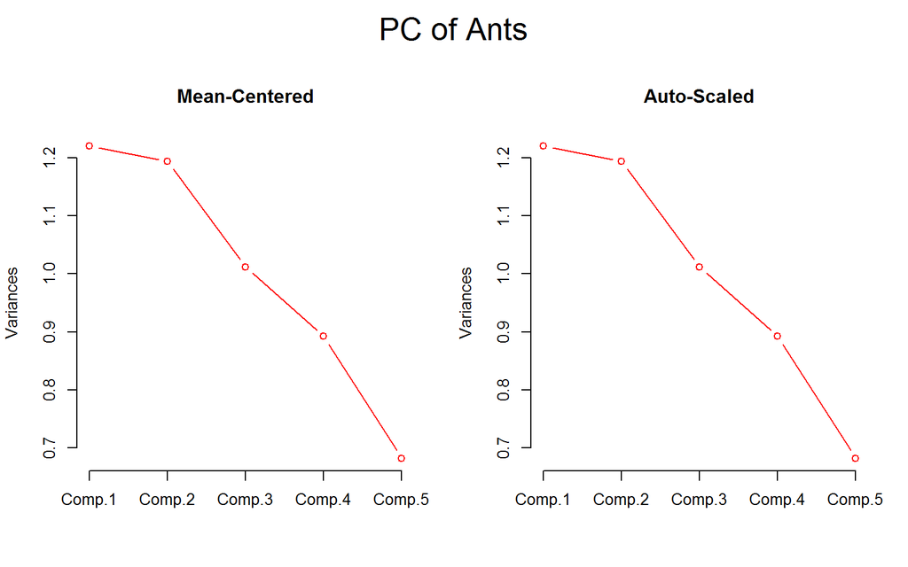

```r
ants_c_pc<-princomp(ants_c,cor=T)
ants_a_pc<-princomp(ants_a,cor=T)
#m<-matrix(c(1,1,2,3),2,2,byrow=TRUE)
layout(m,heights=c(.1,.9))
par(mar=c(0,0,0,0))
plot(5, type = "n", axes=FALSE, xlab="", ylab="")
text(5,labels="PC of Ants",cex=2)
par(mar=c(5,4,4,2)+.1)
screeplot(ants_c_pc,type="lines", col="red", main ="Mean-Centered")
screeplot(ants_a_pc,type="lines", col="red", main ="Auto-Scaled")
```

Plots of the eigenvalues show little difference between mean-centered and auto-scaled data so we will only plot the scores and loadings from mean-centered data. It is highly likely that we will need three principal components to separate the two ant types.

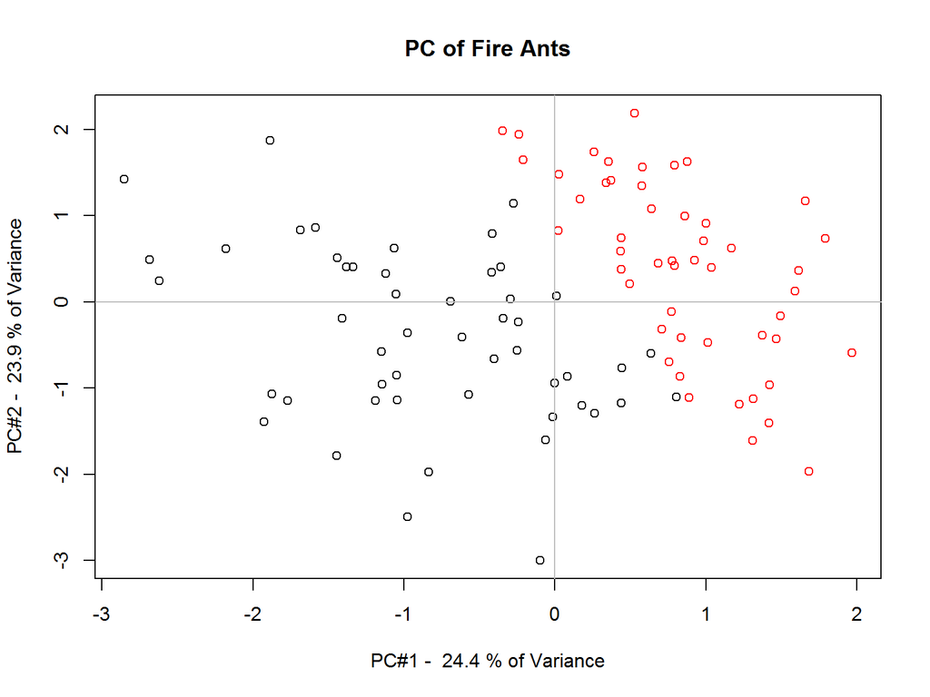

```r
variances <-ants_c_pc$sdev^2/(nrow(ants_c)-1)
totvariances<- sum(variances)
relvars<- variances/totvariances
vars<- 100*round(relvars, digits=3)

par(mfrow=c(1,1))
plot(ants_c_pc$scores[,1],ants_c_pc$scores[,2], col=as.factor(ants_out$Type), xlab=paste("PC#1 - ",vars[1],"% of Variance"), ylab=paste("PC#2 - ",vars[2],"% of Variance"), main="PC of Fire Ants")
abline(h=0, col="gray")
abline(v=0, col="gray")
```

Indeed the first two components mostly separate the two types, but a third may be helpful.

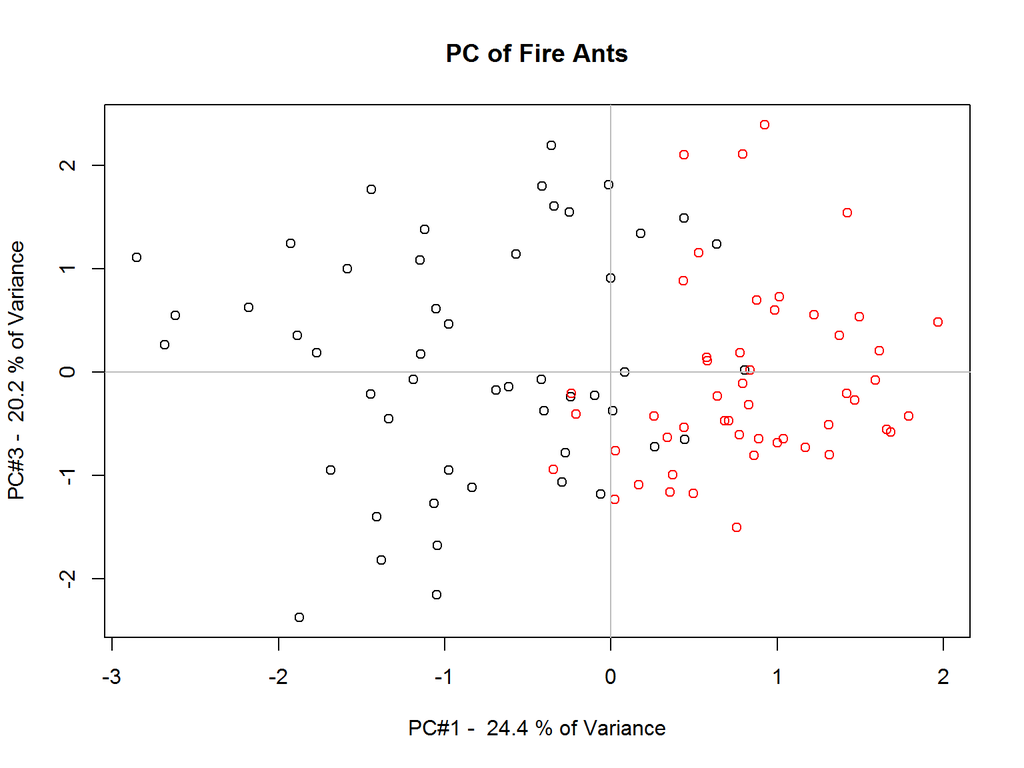

```r
plot(ants_c_pc$scores[,1],ants_c_pc$scores[,3], col=as.factor(ants_out$Type), xlab=paste("PC#1 - ",vars[1],"% of Variance"), ylab=paste("PC#3 - ",vars[3],"% of Variance"), main="PC of Fire Ants")
abline(h=0, col="gray")
abline(v=0, col="gray")
```

It is difficult to see the additional separation in two dimensions.

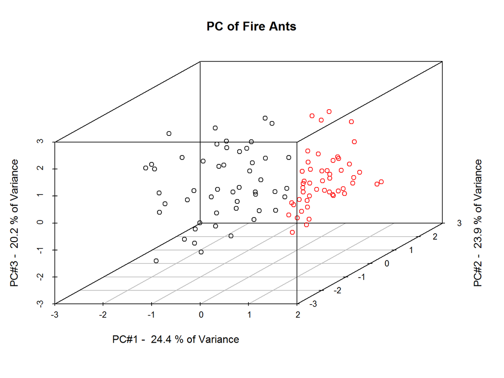

```r
ants_color<-rep(c(1,2),each=50)
scatterplot3d(ants_c_pc$scores[,1],ants_c_pc$scores[,2],ants_c_pc$scores[,3], color=ants_color, angle=45, xlab=paste("PC#1 - ",vars[1],"% of Variance"), ylab=paste("PC#2 - ",vars[2],"% of Variance"), main="PC of Fire Ants", zlab=paste("PC#3 - ",vars[3],"% of Variance"))
```

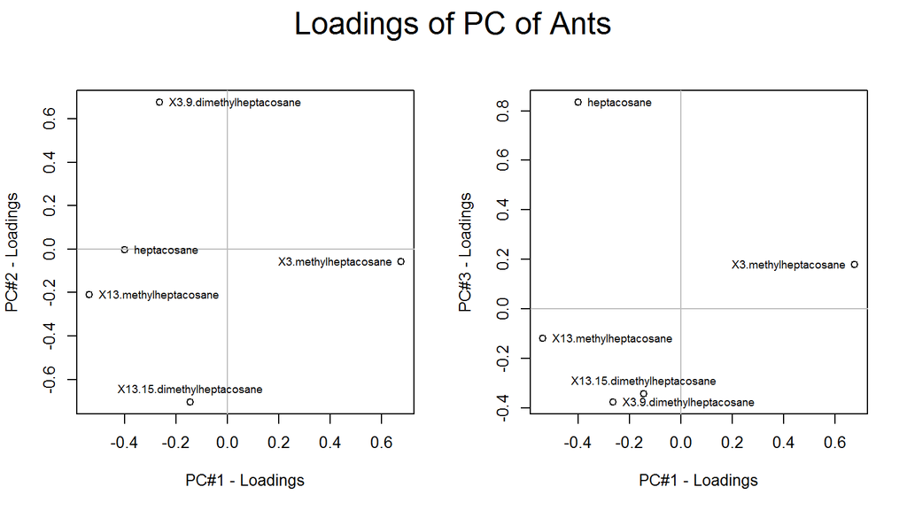

```r
layout(m,heights=c(.1,.9))
par(mar=c(0,0,0,0))
plot(5, type = "n", axes=FALSE, xlab="", ylab="")
text(5,labels="Loadings of PC of Ants",cex=2)
par(mar=c(5,4,2,2)+.1)
plot(ants_c_pc$loadings[,1],ants_c_pc$loadings[,2], xlab="PC#1 - Loadings", ylab="PC#2 - Loadings")
abline(h=0, col="gray")
abline(v=0, col="gray")
text(ants_c_pc$loadings[,1],ants_c_pc$loadings[,2], labels=colnames(ants_out2),pos=c(4,4,3,2,4), cex=0.7)
plot(ants_c_pc$loadings[,1],ants_c_pc$loadings[,3], xlab="PC#1 - Loadings", ylab="PC#3 - Loadings")
abline(h=0, col="gray")
abline(v=0, col="gray")
text(ants_c_pc$loadings[,1],ants_c_pc$loadings[,3], labels=colnames(ants_out2), pos=c(4,4,3,2,4), cex=0.7)
```

## References

1. “JM Bland and DG Altman, Lancet (1995) 346(8982) 1085-1087”
2. Kleinman, K. “Example 9.34: Bland-Altman type plot” June 5, 2012. http://www.r-bloggers.com/example-9-34-bland-altman-type-plot/